# practical machine learning project

Loading dataset

```r
library(caret)
library(dplyr)
```

```r
library(ggplot2)
library(randomForest)
train = read.csv("pml-training.csv")
inTrain <- createDataPartition(y=train$classe, p=0.7, list=FALSE)
training <- train[inTrain,]
testing <- train[-inTrain,]
```

Cleaning data set NAs

```r
trainingNoNa = training[ , colSums(is.na(training)) == 0]
summary(trainingNoNa)
```

[output not shown]

After looking at the data, there are still a lot of incorrect/missing values of the form ‘#DIV/0’. Let’s remove those

```r
trainingNoNaNoDiv0 = trainingNoNa[ , !sapply(trainingNoNa, function(x)any('#DIV/0!' %in% x))]
```

Now looking at what we have left:

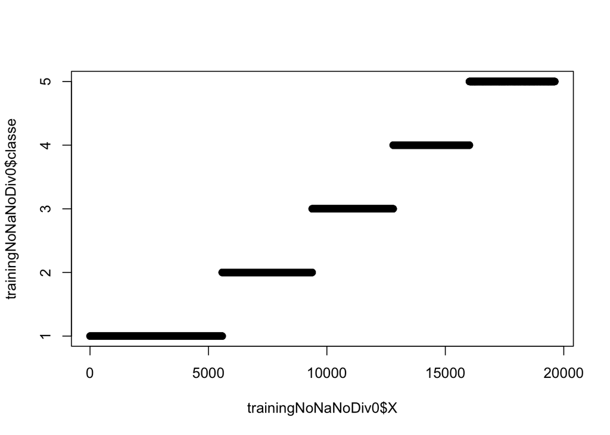

```r
head(trainingNoNaNoDiv0)
summary(trainingNoNaNoDiv0)
plot(trainingNoNaNoDiv0$X, trainingNoNaNoDiv0$classe)
```

X seems to be the rownumber. and the data seems sorted so it would expains 100% of the model. So I remove it. I also removed timestamps columns that don’t make sense in explaining the classe. I also removed “new_window”: that is later on, after training the model the looking a variable importances, this one seemed to have a very low impact so I decided to remove it here and retrain the model.

```r
trainingClean = trainingNoNaNoDiv0 %>% select(-c(X, raw_timestamp_part_1, raw_timestamp_part_2, cvtd_timestamp))

trainingClean2 = trainingClean %>% select(-c(new_window))

summary(trainingClean)
```

Now the data looks nice. I ran a random forest with the randomforest function (caret’s train function never finished).

```r
set.seed(345)
modFit2 = randomForest(classe ~ ., data = trainingClean2, importance = TRUE)
varImp(modFit2)
```

[output not shown]

```r
modFit2
```

```
##
## Call:
##  randomForest(formula = classe ~ ., data = trainingClean2, importance = TRUE)
##                Type of random forest: classification
##                      Number of trees: 500
## No. of variables tried at each split: 7
##
##         OOB estimate of  error rate: 0.23%
## Confusion matrix:
##      A    B    C    D    E class.error
## A 3906    0    0    0    0 0.000000000
## B    4 2652    2    0    0 0.002257336
## C    0    8 2388    0    0 0.003338898
## D    0    0   13 2238    1 0.006216696
## E    0    0    0    3 2522 0.001188119
```

Now let’s see our out of sample error.

```r
preds <- predict(modFit2, newdata=testing)
confusionMatrix(testing$classe, preds)
```

```
## Confusion Matrix and Statistics
##
##           Reference
## Prediction    A    B    C    D    E
##          A 1674    0    0    0    0
##          B    2 1137    0    0    0
##          C    0    3 1023    0    0
##          D    0    0   11  952    1
##          E    0    0    0    3 1079
##
## Overall Statistics
##
##                Accuracy : 0.9966
##                  95% CI : (0.9948, 0.9979)
##     No Information Rate : 0.2848
##     P-Value [Acc > NIR] : < 2.2e-16
##
##                   Kappa : 0.9957
##  Mcnemar's Test P-Value : NA
##
## Statistics by Class:
##
##                      Class: A Class: B Class: C Class: D Class: E
## Sensitivity            0.9988   0.9974   0.9894   0.9969   0.9991
## Specificity            1.0000   0.9996   0.9994   0.9976   0.9994
## Pos Pred Value         1.0000   0.9982   0.9971   0.9876   0.9972
## Neg Pred Value         0.9995   0.9994   0.9977   0.9994   0.9998
## Prevalence             0.2848   0.1937   0.1757   0.1623   0.1835
## Detection Rate         0.2845   0.1932   0.1738   0.1618   0.1833
## Detection Prevalence   0.2845   0.1935   0.1743   0.1638   0.1839
## Balanced Accuracy      0.9994   0.9985   0.9944   0.9972   0.9992
```

Now the first part is done and we need to load the test set, make predictions on it and submit.